# R基础绘图

### 平行线段segments()

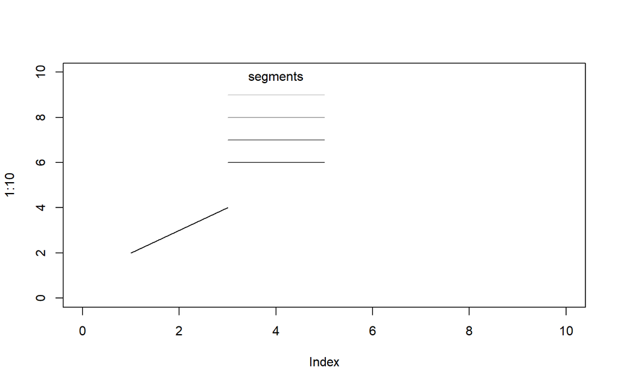

```r
plot(1:10, type = "n", xlim = c(0, 10), ylim = c(0,10))
segments(1,2,3,4)
segments(rep(3, 4), 6:9, rep(5, 4), 6:9, col = gray(seq(0.2,0.8, length = 4)))
text(4, 9.8, "segments")
```

### 网格grid()

在图形中添加网格线，nx，ny分别表示垂直于x轴和y轴的网格，NULL表示保留，NA表示删掉。

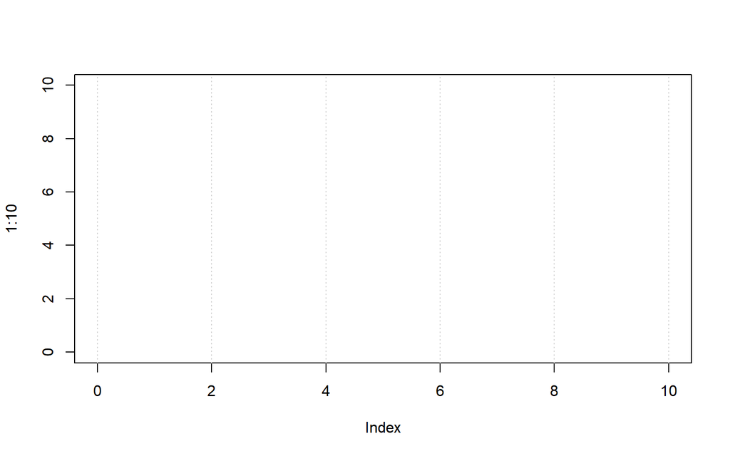

```r
plot(1:10, type = "n", xlim = c(0, 10), ylim = c(0,10))
grid(nx = NULL,ny = NA)
```

## 基本图形

### 散点图

两个变量之间的关系，这种关系可能是线性或非线性的,画一个人造数据的散点图：我们设计了2万个样本，其中有1万个样本点来自于两个独立的标准正态分布，另1万个样本点的坐标落在半径为0.5的圆上，最后将这2万个样本拼起来并打乱顺序。

```r
# install.packages('MSG') 需要先下载R的数据包MSG
library(MSG)
```

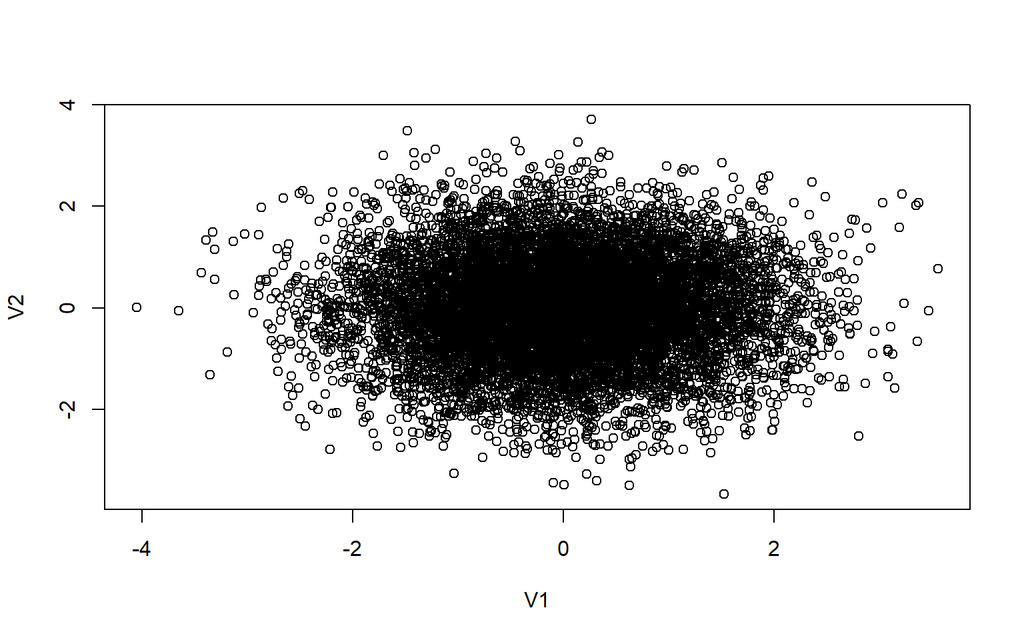

```r
data(BinormCircle)
plot(BinormCircle)
```

### 直方图hist()

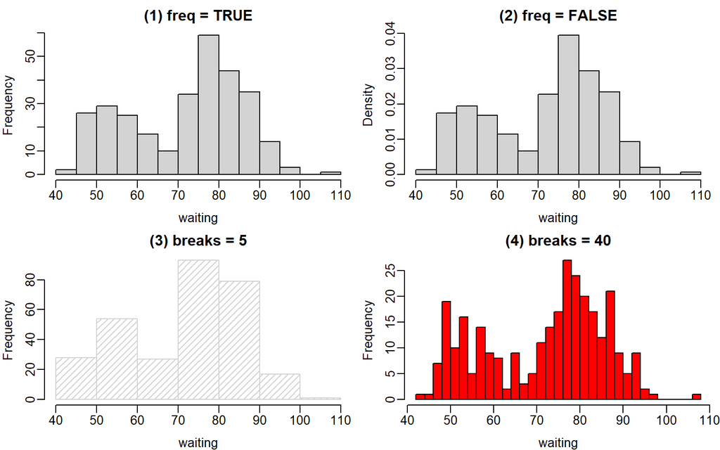

```r
library(MASS)
data(geyser)
par(mfrow = c(2,2), mar = c(3,3,2,0.5), mgp = c(2, 0.5, 0))
hist(geyser$waiting, main = "(1) freq = TRUE", xlab = "waiting")
hist(geyser$waiting, freq = FALSE, main = "(2) freq = FALSE", xlab = "waiting")
hist(geyser$waiting, breaks = 5, density = 20, xlab = "waiting", main = "(3) breaks = 5") #
hist(geyser$waiting, breaks = 40, col = "red", xlab = "waiting", main = "(4) breaks = 40")
```

### 箱线图boxplot()

箱线图,从四分位数的角度 出发描述数据的分布，它通过最大值（Q4）、上四分位数（Q3）、中位数 （Q2）、下四分位数（Q1）和最小值（Q0）五处位置来获取一维数据的分布概况。以datasets包 中的杀虫剂数据InsectSprays为例；该数据有两列，第一列为昆虫数目，第二列为杀虫剂种类（ABCDEF），这里是随机抽取的10列数据：

```r
InsectSprays[sample(nrow(InsectSprays), 10), ]
```

```
##    count spray
## 17    16     B
## 40     6     D
## 65    15     F
## 31     2     C
## 1     10     A
## 69    26     F
## 64    22     F
## 11    14     A
## 66    16     F
## 6     12     A
```

```r
InsectSprays
```

```
##    count spray
## 1     10     A
## 2      7     A
## 3     20     A
## 4     14     A
## 5     14     A
## 6     12     A
## 7     10     A
## 8     23     A
## 9     17     A
## 10    20     A
## 11    14     A
## 12    13     A
## 13    11     B
## 14    17     B
```

[output cut: 58 more lines]

```r
x <- InsectSprays[,1]
```

将所有的昆虫数目作为样本，进行绘图如下：

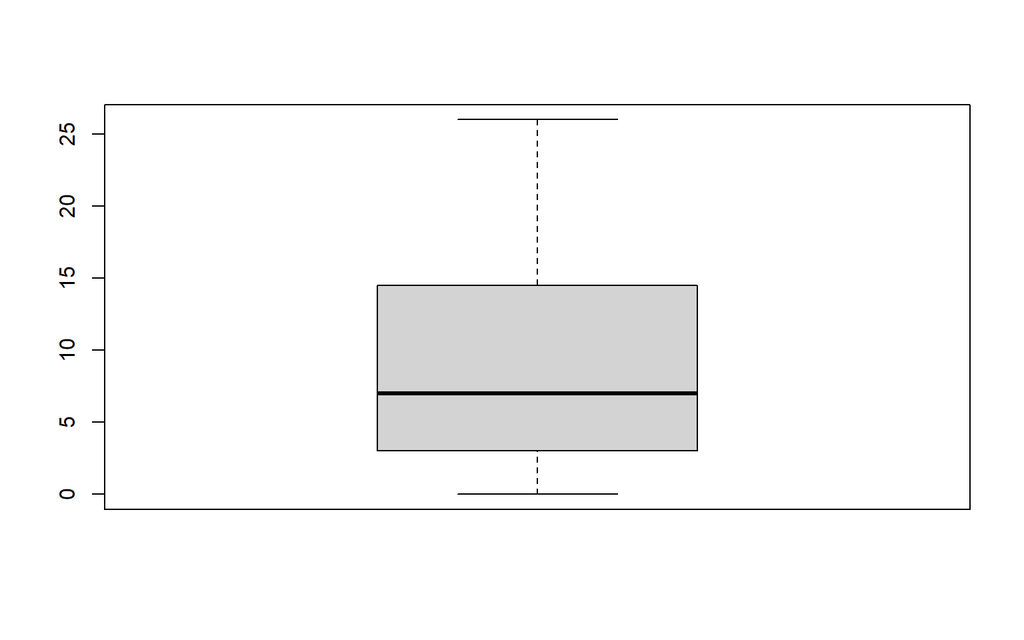

```r
boxplot(x)
```

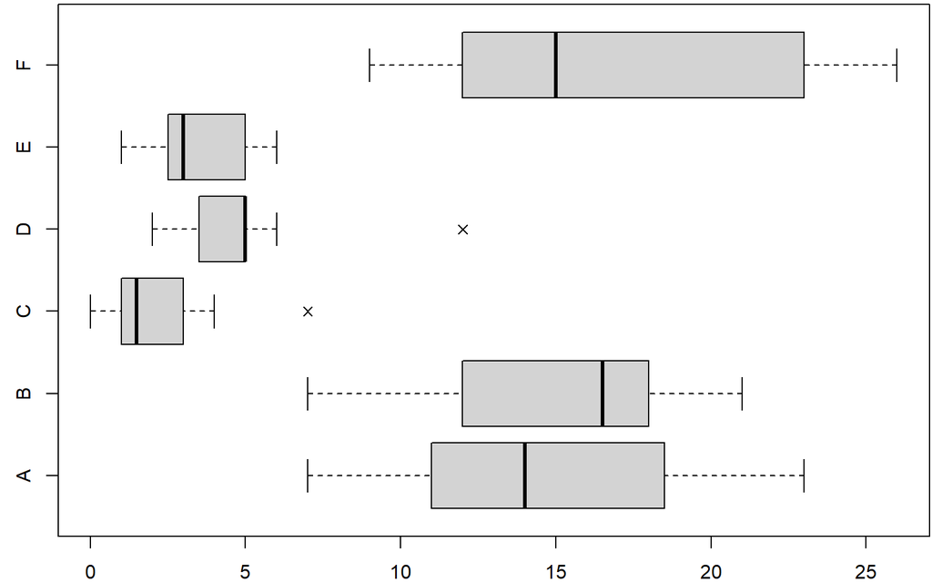

```r
par(mar = c(2, 2.5, 0.2, 0.1))
boxplot(count ~ spray, data = InsectSprays, col = "lightgray",
        horizontal = T, pch = 4) #horizontal = T横向
```

### 条形图barplot()

条形图,能以矩形条的长度展示 原始数值，对数据没有任何概括或推断。VADeaths是R自带的一个数据包，里面包含了1940年弗吉尼亚州分年龄组、分地区和分性别死亡率数据。

```r
data(VADeaths)
#install.packages('RColorBrewer')
library(RColorBrewer) #调用调色板
par(mfrow = c(2, 1), mar = c(3, 2.5, 0.5, 0.1))
death = t(VADeaths)[, 5:1] #转置、重新排列年龄段
death
```

```
##              70-74 65-69 60-64 55-59 50-54
## Rural Male    66.0  41.0  26.9  18.1  11.7
## Rural Female  54.3  30.9  20.3  11.7   8.7
## Urban Male    71.1  54.6  37.0  24.3  15.4
## Urban Female  50.0  35.1  19.3  13.6   8.4
```

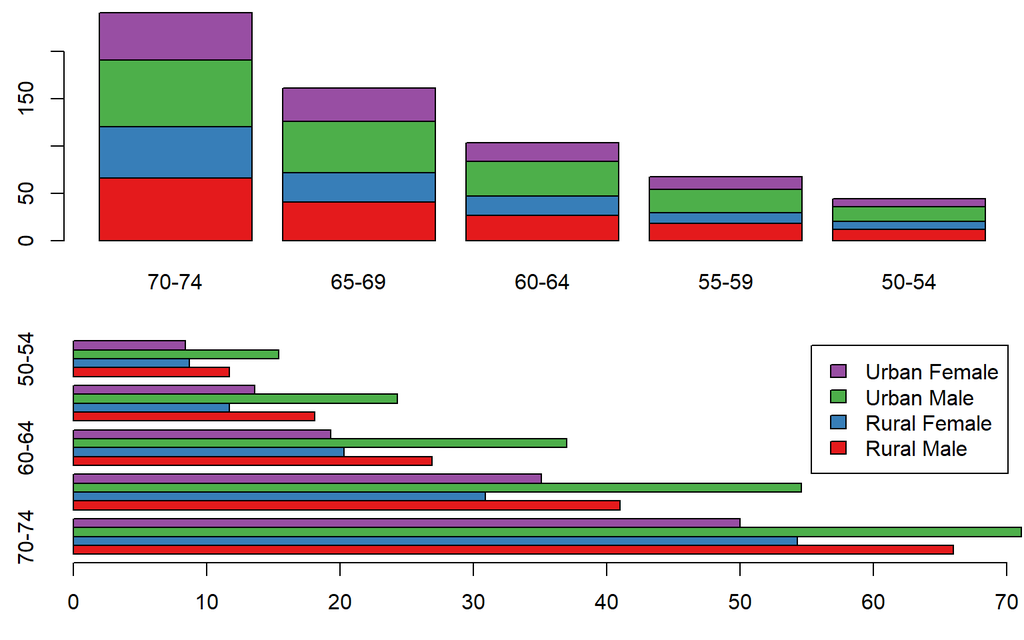

```r
barplot(death, col = brewer.pal(4, "Set1"))
barplot(death, col = brewer.pal(4, "Set1"),
        beside = TRUE, #beside相邻，不堆叠
        legend = TRUE,#length图例
        horiz = T) #length图例
```

```r
par(mfcol = c(1,2))
x <- c(95,26,36,78,25,65)
labels <- c("a", "b", "c","d", "e", "f")
pie(x,labels,main = 'Simple Pie Chart')
pct <- round(x/sum(x)*100) #转化百分比
labels2 <- paste(labels,' ',pct,'%',sep = '') #paste连接函数,seperate
labels2
```

```
## [1] "a 29%" "b 8%"  "c 11%" "d 24%" "e 8%"  "f 20%"
```

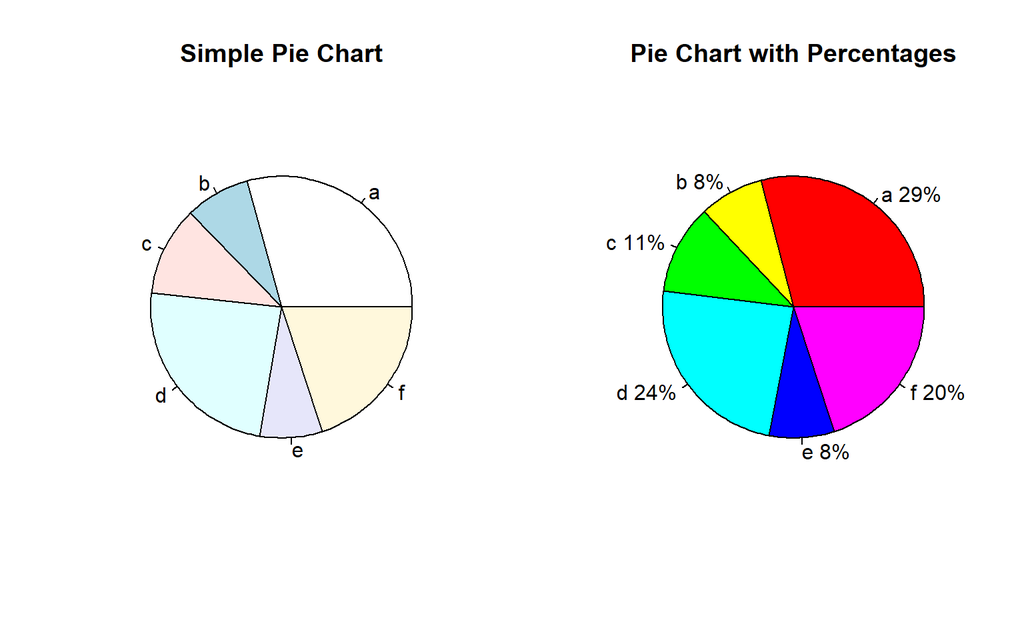

```r
pie(pct,labels2,col = rainbow(length(labels2)),main = 'Pie Chart with Percentages')
```

以上绘制的是二维的饼图，R也可以绘制三维的饼图，但是我认为三维饼图与二维饼图相比较，除了视觉效果不同，不能包含更多的数据信息，所以这里没有深入讨论三维饼图。如果有人感兴趣，可以自己研究一下。三维饼图会用到plotrix这个包，需要下载，函数是pie3D(x,labels,explode = 0.1,main = ‘3D Pie Chart’)。

### 函数图curve()

函数图在金融里面的应用还是非常多的，这里只画了sin(x),cos(x)这两个基础函数，以及一些基本参数的设置：

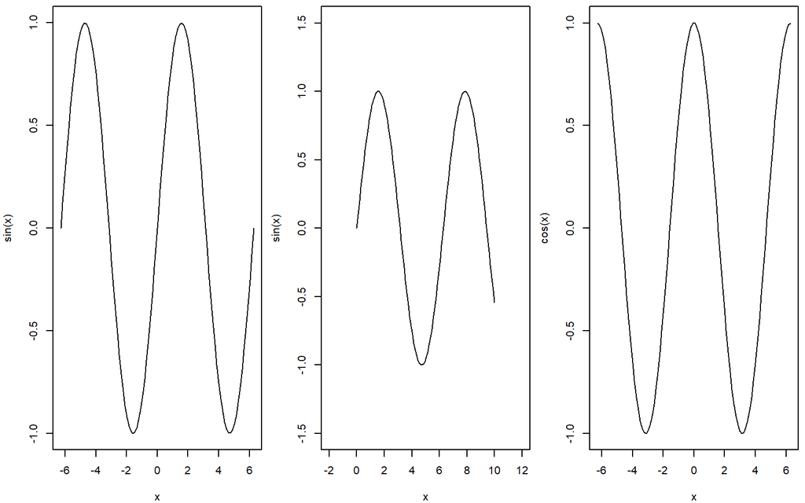

```r
par(mfcol = c(1,3),mar = c(4,4,0.5,0.5))
curve(sin(x), from = -2*pi, to = 2*pi, n = 100)
curve(sin(x), from = 0, to = 10, n = 100, add = F,
      type = 'l', xlab = 'x', ylab = 'sin(x)',xlim = c(-2,12), ylim = c(-1.5,1.5))
curve(cos(x), from = -2*pi, to = 2*pi, n = 100)
```

### 地图map()地图

先来看看map()函数的世界地图和美国地图，地图数据包含在maps这个包里：

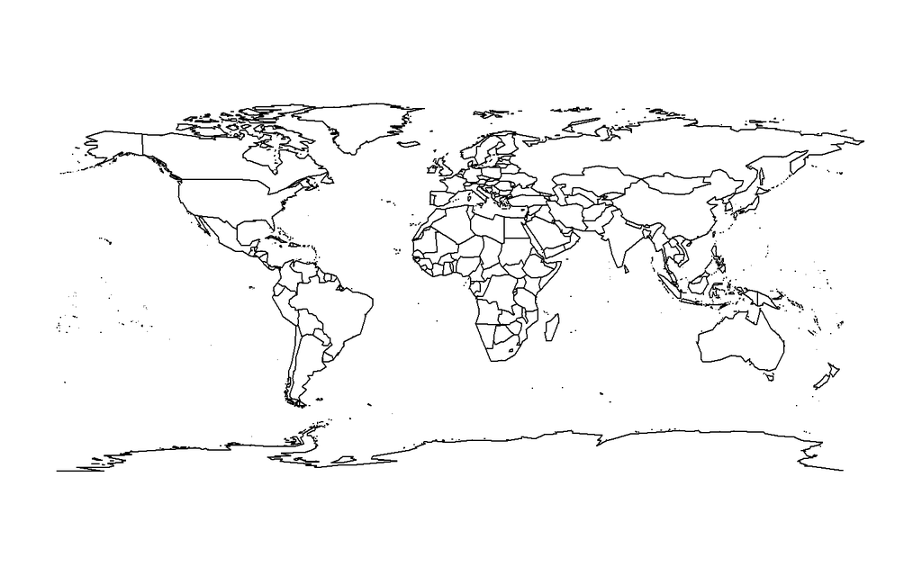

```r
# install.packages('maps')
library('maps')
map('world')
```

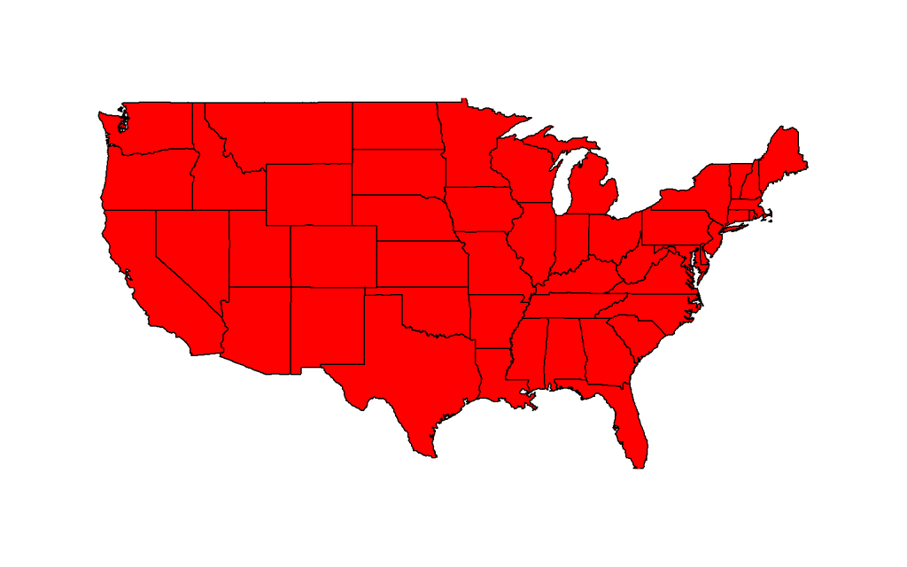

```r
map('state',boundary = T,col = 'red',fill = T)
```

将数据进行可视化，在地图中呈现出来的效果，先调整地图的大小范围：

```r
#install.packages('geosphere') #绘图的包，用到里面的弧线连线函数
library('geosphere')
```

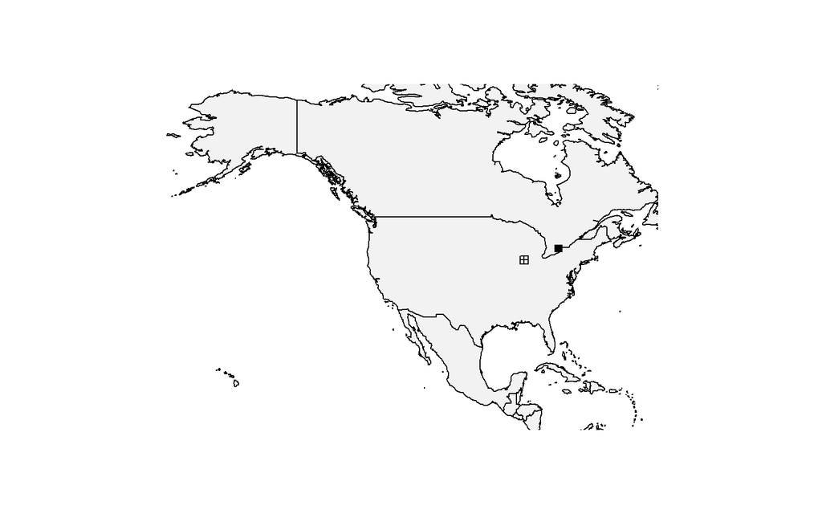

```r
#设置坐标范围使焦点集中在美国周边，并且设置一些有关颜色
xlim <- c(-171.738, -56.602)#经度
ylim <- c(12.039,71.856)#纬度
map('world', col = '#f2f2f2', fill = T, bg = 'white', xlim = xlim, ylim = ylim)

#给定点的位置，在地图中标注出来，比如芝加哥坐标北纬41°39′、西经87°34′,加拿大多伦多北纬43度39分，西经79度23分
points(-87.34,41.39,pch = 12)
points(-79.23,43.39,pch = 15)
```

因为图片中表示的范围太大，难以找到对应的点，调小显示图的范围，再把这两点用弧线连接起来：

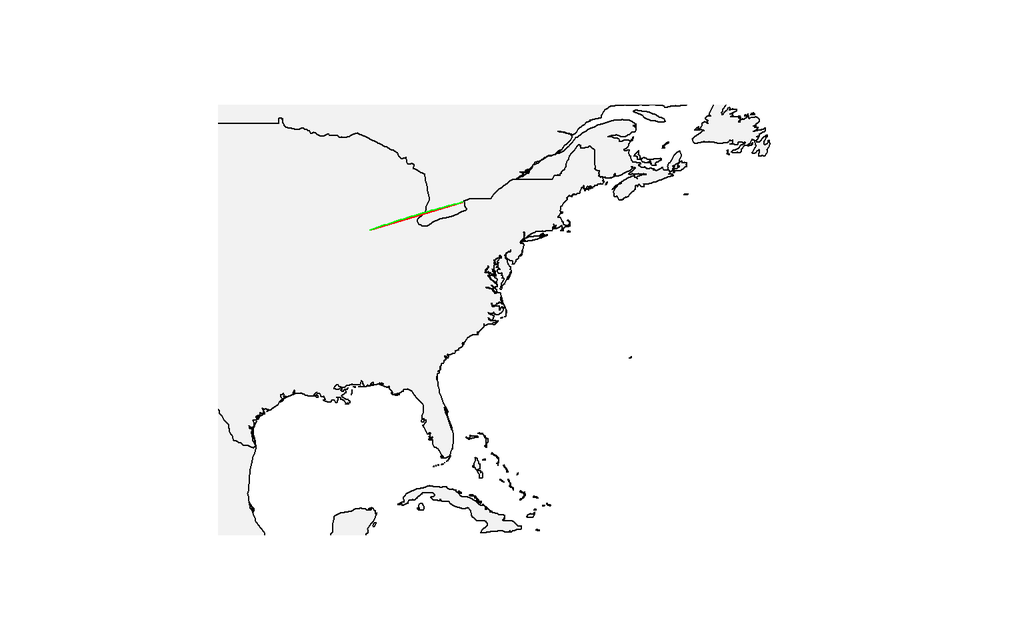

```r
#调整经纬度范围
xlim <- c(-100,-50)#经度
ylim <- c(20,50)#纬度
map('world', col = '#f2f2f2', fill = T, bg = 'white', xlim = xlim, ylim = ylim)

#画一条弧线连线，表示社交关系
lon_ca <- -87.34 #longitude 经度
lat_ca <- 41.39 #latitudu 纬度
lon_me <- -79.23
lat_me <- 43.39
lines(c(-87.34,-79.23),c(41.39,43.39),col='red')
inter<- gcIntermediate(c(lon_ca, lat_ca), c(lon_me, lat_me), addStartEnd=TRUE) #addStartEnd=TRUE 连接起始点
lines(inter, col='green')
```

这种在地图上用弧线连接两点，经常用来表示飞机的航线，我们用网上的一些航线数据来作图：

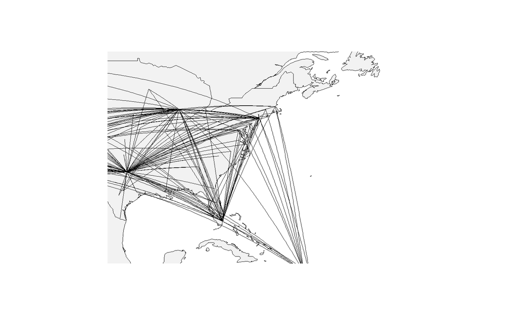

```r
#装载数据
airports <- read.csv("http://datasets.flowingdata.com/tuts/maparcs/airports.csv", header=TRUE)
flights <- read.csv("http://datasets.flowingdata.com/tuts/maparcs/flights.csv", header=TRUE, as.is=TRUE)
map("world", col="#f2f2f2", fill=TRUE, bg="white", lwd=0.05, xlim=xlim, ylim=ylim)

fsub <- flights[flights$airline == "AA",]
for (j in 1:length(fsub$airline)) {
  air1 <- airports[airports$iata == fsub[j,]$airport1,]
  air2 <- airports[airports$iata == fsub[j,]$airport2,]
  inter <- gcIntermediate(c(air1[1,]$long, air1[1,]$lat), c(air2[1,]$long, air2[1,]$lat), n=100, addStartEnd=TRUE)
  lines(inter, col="black", lwd=0.8)
}
```

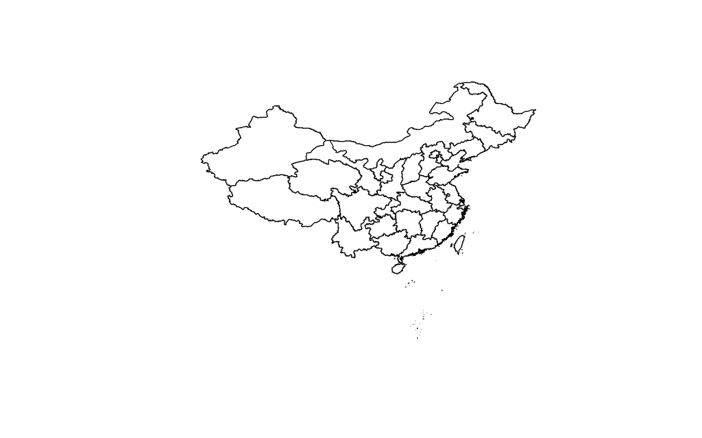

```r
#R语言地图绘制，底图+数据，会用到ggplot2，暂时跳过
#install.packages('rgdal')
library('rgdal')
#install.packages('mapdata')
library('mapdata')
#install.packages('maptools')
library('maptools')
#install.packages('ggplot2')
library('ggplot2')
#设置路径工作路径
x<-readOGR('./data/bou2_4p.shp',stringsAsFactors=F)
# head(x) # x
plot(x)
```

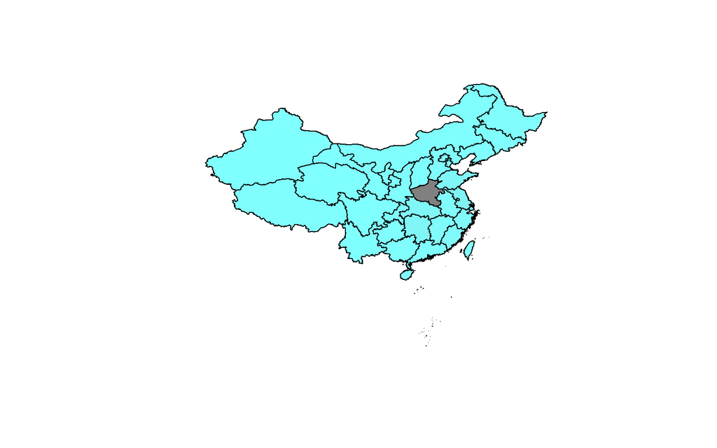

```r
#设置颜色
getColor = function(x, provname, provcol){
  f = function(x, y) ifelse(x %in% y, which(y == x), 0);
  colIndex = sapply(x@data$NAME, f, provname);
  col = c(provcol)[colIndex + 1];
  return(col);
}
provname =c ("北京市", "天津市", "河北省", "山西省", "内蒙古自治区","辽宁省", "吉林省", "黑龙江省", "上海市", "江苏省","浙江省", "安徽省", "福建省", "江西省", "山东省","河南省", "湖北省", "湖南省", "广东省","广西壮族自治区", "海南省", "重庆市", "四川省", "贵州省","云南省", "西藏自治区", "陕西省", "甘肃省", "青海省","宁夏回族自治区", "新疆维吾尔自治区", "台湾省","香港特别行政区")
pop=c(111,28,65,35,18,39,14,43,101,129,428,200,101,162,145,278,4586,277,311,78,46,165,142,12,70,1,63,26,6,12,14,8,10)
provcol = rgb(blue = 1 - pop/max(pop)/2, green = 1-pop/max(pop)/2, red = 0.5)
#最关键的上色
plot(x, col= getColor(x, provname, provcol), xlab = "", ylab = "")
```